# Clustering Analysis

```python
import pandas as pd
from sklearn.cluster import KMeans
from sklearn.preprocessing import StandardScaler
import matplotlib.pyplot as plt
import seaborn as sns
from sklearn.metrics import silhouette_score
```

```python
df = pd.read_csv("../data/religion_data.csv")
df.head()
```

|  | P_SUID | YEAR_FROM_CODATE | HAPPY | SATIS_A | SATIS_B | CHNG_A | CHNG_B | CHNG_C | DIVRELPOP | DIVRACPOP | ... | MOVED | REG | PARTY | IDEO | HH1REC | INTFREQ | INC_SDT1 | GENDER | FERTREC | WEIGHT |
| --- | --- | --- | --- | --- | --- | --- | --- | --- | --- | --- | --- | --- | --- | --- | --- | --- | --- | --- | --- | --- | --- |
| 0 | 10000040 | 2023 | 1 | 2 | 2 | 2 | 3 | 2 | 2 | 3 | ... | 1 | 1 | 1 | 1 | 3 | 2 | 2 | 2 | 1 | 4399.707781 |
| 1 | 10000060 | 2023 | 1 | 2 | 1 | 1 | 1 | 1 | 1 | 1 | ... | 2 | 1 | 2 | 5 | 3 | 2 | 7 | 2 | 2 | 6693.424549 |
| 2 | 10000140 | 2024 | 2 | 2 | 3 | 3 | 1 | 1 | 1 | 1 | ... | 1 | 1 | 3 | 3 | 2 | 1 | 7 | 2 | 0 | 3080.916226 |
| 3 | 10000150 | 2023 | 3 | 3 | 3 | 2 | 1 | 2 | 3 | 1 | ... | 2 | 1 | 1 | 3 | 2 | 2 | 99 | 2 | 2 | 5470.685158 |
| 4 | 10000160 | 2023 | 3 | 1 | 1 | 3 | 1 | 2 | 1 | 1 | ... | 2 | 1 | 2 | 4 | 2 | 1 | 5 | 2 | 2 | 2474.921511 |

5 rows × 107 columns

## Selecting Relevant Features

```python
features = [
    'CHNG_C',        # Views on transgender people
    'DIVRELPOP',     # Diversity of religion in society
    'DIVRACPOP',     # Diversity of race in society
    'QB2A', 'QB2C', 'QB2D',  # Values: homosexuality, environment, right/wrong
    'OPENIDEN', 'POORASSIST', 'GOVSIZE1',
    'ABRTLGL', 'GAYMARR',  # Abortion & gay marriage
    'CLIM1A', 'EVOL',      # Climate & evolution
    'GUIDE_B', 'GUIDE_C', 'GUIDE_D',  # Logic, science, common sense
    'MARITAL', 'CHILDREN', 'GENDER', 'BIRTHDECADE',
    'EDUCREC', 'EMPLSIT', 'USGEN', 'REG', 'PARTY', 'IDEO',
    'HH1REC', 'INTFREQ', 'INC_SDT1'
]
```

## K-Means

We applied KMeans clustering to a set of respondents using a range of non-religious socio-political and demographic features, including views on gender and sexuality, political ideology, education, income, attitudes toward science and government, and more. The goal was to determine whether individuals naturally group into distinct sociocultural profiles — and to assess how those profiles correspond (if at all) with religious tradition (RELTRAD).

### Optimal # of CLusters

First we attempted to find optimal`k` with elbow method but it’s not exactly clear, possible `k=5`.

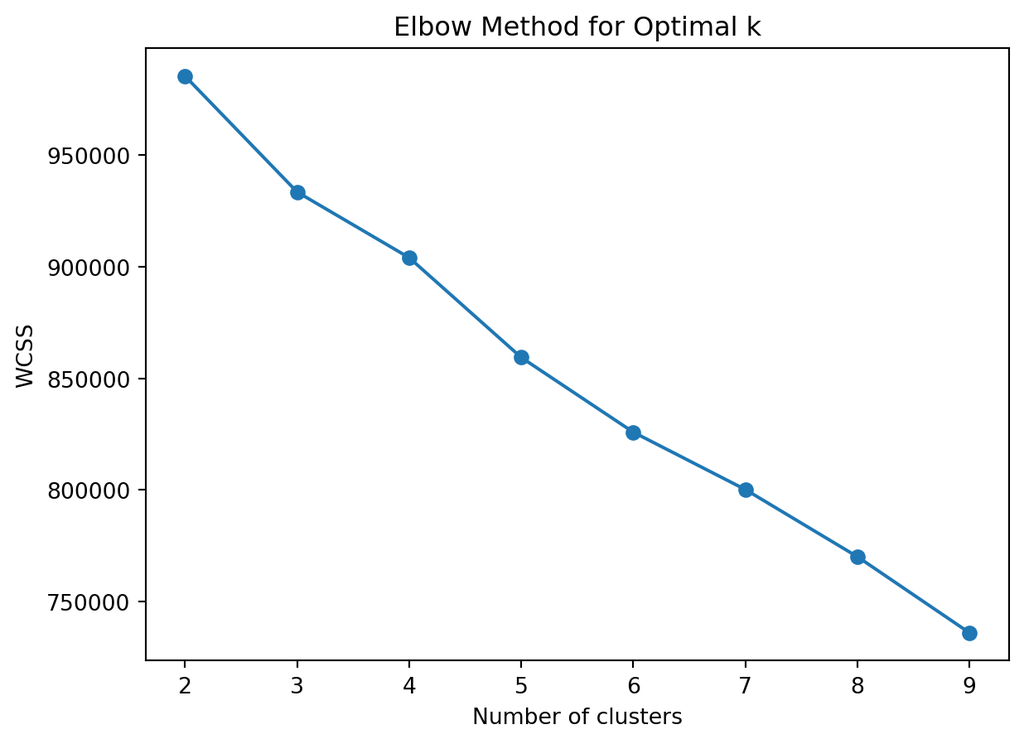

```python
X = df[features].dropna()  # Drop rows with missing values

# Keep original indices to map back religion
df_clean = df.loc[X.index]

# Scale features
scaler = StandardScaler()
X_scaled = scaler.fit_transform(X)

# Elbow Method to choose k
wcss = []
for i in range(2, 10):
    kmeans = KMeans(n_clusters=i, random_state=42)
    kmeans.fit(X_scaled)
    wcss.append(kmeans.inertia_)

plt.plot(range(2, 10), wcss, marker='o')
plt.title("Elbow Method for Optimal k")
plt.xlabel("Number of clusters")
plt.ylabel("WCSS")
plt.show()
```